# Classifying exercise execution quality from motion tracking data

August 2014

### Summary

In this report we find good classification models for exercise execution quality from motion tracking data. The data for this study is obtained from [here](http://groupware.les.inf.puc-rio.br/har), used in [1]. From the data exploration we found that there are substantial differences between the users regarding values of some variables, due to differences in anthropometrics. Using insight that test-set presents data about identical individuals as in the training set, we tried out kNN algorithm that should use specific users’ anthropometric characteristics. SVM model, well known good performing robust classifier, has even more impressive performance on this dataset and it seems to also extract user specifics so it should work well on new data from those users. Finally, streching the data even more, to the extremes, after seeing specifics of the relation between the test and training set, we constructed a trivial classifier that should have the best performance on the given test set with this training data.

### Data processing and exploration

```r
library(knitr)
opts_chunk$set(cache=T)
options(scipen=1,digits=7)
mov1=read.csv("pml-training.csv")
mov2=read.csv("pml-testing.csv")

names(mov1)
```

```
##   [1] "X"                        "user_name"
##   [3] "raw_timestamp_part_1"     "raw_timestamp_part_2"
##   [5] "cvtd_timestamp"           "new_window"
##   [7] "num_window"               "roll_belt"
##   [9] "pitch_belt"               "yaw_belt"
##  [11] "total_accel_belt"         "kurtosis_roll_belt"
##  [13] "kurtosis_picth_belt"      "kurtosis_yaw_belt"
##  [15] "skewness_roll_belt"       "skewness_roll_belt.1"
##  [17] "skewness_yaw_belt"        "max_roll_belt"
##  [19] "max_picth_belt"           "max_yaw_belt"
##  [21] "min_roll_belt"            "min_pitch_belt"
##  [23] "min_yaw_belt"             "amplitude_roll_belt"
##  [25] "amplitude_pitch_belt"     "amplitude_yaw_belt"
##  [27] "var_total_accel_belt"     "avg_roll_belt"
##  [29] "stddev_roll_belt"         "var_roll_belt"
```

[output cut: 65 more lines]

The supplied labeled dataset has 19622 observations and 160 variables. But, the most of the observations miss summary statistics data. As all the observations in the test set also do not have this information we remove those columns from the dataset. We also remove the columns holding the observationID, time related markers/variables, and *num_window* as these hold the time information which should not be relevant if we would like to do exercises in the future and classify our execution quality.

```r
cols=grep("max|min|amplitude|kurtosis|avg|var|stddev|skewness",names(mov1))
mov1.filtered=mov1[,-c(cols,1,3,4,5,6,7)]
```

Now, we split the data into the training set and labeled test set. The latter we will use to estimate out-of-sample accuracy.

```r
set.seed(12)
inTrain=createDataPartition(y=mov1.filtered$classe,p=0.7,list=F)

trainMov=mov1.filtered[inTrain,]
testMov=mov1.filtered[-inTrain,]
```

From now on we use only the training set, until specified otherwise.

We shall check several boxplots to see how do the values look for specific user and exercise quality class.

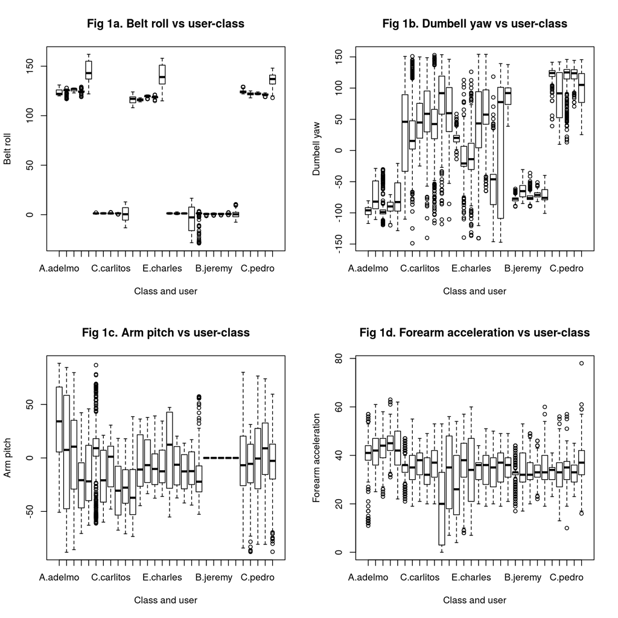

```r
par(mfrow=c(2,2))
with(mov1[inTrain,],boxplot(roll_belt~classe+user_name, main="Fig 1a. Belt roll vs user-class"
                            ,xlab="Class and user",ylab="Belt roll"))

with(mov1[inTrain,],boxplot(yaw_dumbbell~classe+user_name, main="Fig 1b. Dumbell yaw vs user-class"
                            ,xlab="Class and user",ylab="Dumbell yaw"))

with(mov1[inTrain,],boxplot(pitch_arm~classe+user_name, main="Fig 1c. Arm pitch vs user-class"
                            ,xlab="Class and user",ylab="Arm pitch"))
with(mov1[inTrain,],boxplot(total_accel_forearm~classe+user_name, main="Fig 1d. Forearm acceleration vs user-class"
                            ,xlab="Class and user",ylab="Forearm acceleration"))
```

```r
par(mfrow=c(1,1))
```

We can see that there are substantial differences between the users regarding values of some variables, due to differences in anthropometrics.

Let’s see if there is the relationship between observation order and classe in the training set.

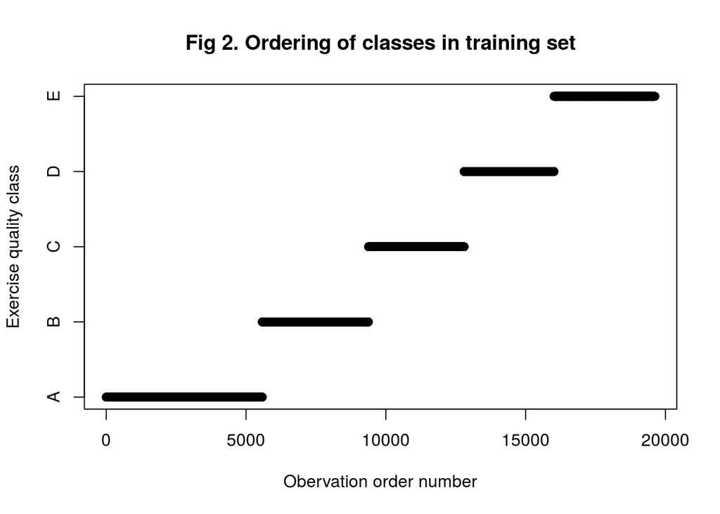

```r
plot(mov1[inTrain,]$X,mov1[inTrain,]$classe,main="Fig 2. Ordering of classes in training set",xlab="Obervation order number",
     ylab="Exercise quality class",yaxt='n')
axis(side=2, at=1:5, labels=levels(mov1$classe))
```

### kNN model

Looking into unlabeled test set we can see that all the records describe the identical set of individuals as the training set so we can learn using the user anthropometric specifics. kNN seems as good candidate for using these specifics. As we will use the cross-validation, we shuffle the rows in training set to break possible bias in folds (Fig 2.).

```r
N=length(names(mov1.filtered))

set.seed(222)
shuffle1=sample(nrow(trainMov))
```

We use the cross-validation to select the value of parameter k from the set of {1,3,5,7,9}.

```r
ctrl <- trainControl(method = "cv", number=5)
cl <- makeCluster(detectCores())
registerDoParallel(cl)
mod.knn=train(trainMov$classe[shuffle1]~.,data=trainMov[shuffle1,],method="knn",preProcess=c("center","scale"),trControl=ctrl,tuneGrid = expand.grid(.k=c(1,3,5,7,9)))
stopCluster(cl)
mod.knn
```

```
## k-Nearest Neighbors
##
## 13737 samples
##    53 predictors
##     5 classes: 'A', 'B', 'C', 'D', 'E'
##
## Pre-processing: centered, scaled
## Resampling: Cross-Validated (5 fold)
##
## Summary of sample sizes: 10989, 10990, 10991, 10990, 10988
##
## Resampling results across tuning parameters:
##
##   k  Accuracy  Kappa  Accuracy SD  Kappa SD
##   1  0.985     0.981  0.00260      0.00328
##   3  0.970     0.962  0.00264      0.00333
##   5  0.956     0.944  0.00280      0.00354
##   7  0.943     0.928  0.00525      0.00666
##   9  0.932     0.914  0.00598      0.00759
##
## Accuracy was used to select the optimal model using  the largest value.
## The final value used for the model was k = 1.
```

The best model has **k=1** and *estimated accuracy=0.984858*.

### SVM model

SVM is known for it’s great out-of-box performance in classification, so we create model to see if it can top kNN model. Using crossvalidation we choose the *C* and *sigma* parameters and due to high computational demands we use paralelization and rather small tuning grid.

```r
ctrl <- trainControl(method = "cv", number=5)
cl <- makeCluster(detectCores())
registerDoParallel(cl)
mod.svm=train(trainMov$classe[shuffle1]~.,data=trainMov[shuffle1,],method="svmRadial",preProcess=c("center","scale"),trControl=ctrl,tuneGrid = expand.grid(.sigma=c(0.01,0.02),.C=c(1,100,200)))
stopCluster(cl)
mod.svm
```

```
## Support Vector Machines with Radial Basis Function Kernel
##
## 13737 samples
##    53 predictors
##     5 classes: 'A', 'B', 'C', 'D', 'E'
##
## Pre-processing: centered, scaled
## Resampling: Cross-Validated (5 fold)
##
## Summary of sample sizes: 10990, 10990, 10989, 10990, 10989
##
## Resampling results across tuning parameters:
##
##   sigma  C    Accuracy  Kappa  Accuracy SD  Kappa SD
##   0.01     1  0.910     0.886  0.008316     0.01059
##   0.01   100  0.990     0.987  0.001897     0.00240
##   0.01   200  0.992     0.990  0.001491     0.00189
##   0.02     1  0.943     0.928  0.006103     0.00776
##   0.02   100  0.993     0.991  0.000941     0.00119
##   0.02   200  0.992     0.990  0.001297     0.00164
##
## Accuracy was used to select the optimal model using  the largest value.
## The final values used for the model were sigma = 0.02 and C = 100.
```

The selected model has **C=100**, **sigma=0.02** and *estimated accuracy=0.992648*.

```r
ctrl=trainControl(method="none")
sum=0
for(i in levels(trainMov$user_name)){

  temp=trainMov[trainMov$user_name!=i,]
  temp_test=trainMov[trainMov$user_name==i,]

  mod.svm_t=train(temp$classe~.,data=temp[,-c(1,N)],method="svmRadial",preProcess=c("center","scale"),trControl=ctrl,tuneGrid = expand.grid(.sigma=mod.svm$bestTune$sigma,.C=mod.svm$bestTune$C))

  sum=sum+accuracy(predict(mod.svm_t, newdata=temp_test[,-c(1,N)]),temp_test$classe)
  }
sprintf('Estimated accuracy: %f',sum/5)
```

```
## [1] "Estimated accuracy: 0.363832"
```

The estimated accuracy is much lower in this case which means that our SVM model bases its good performance on user specifics, just like kNN model.

### Trivial model

Let’s look at the **num_window vs classe** plot:

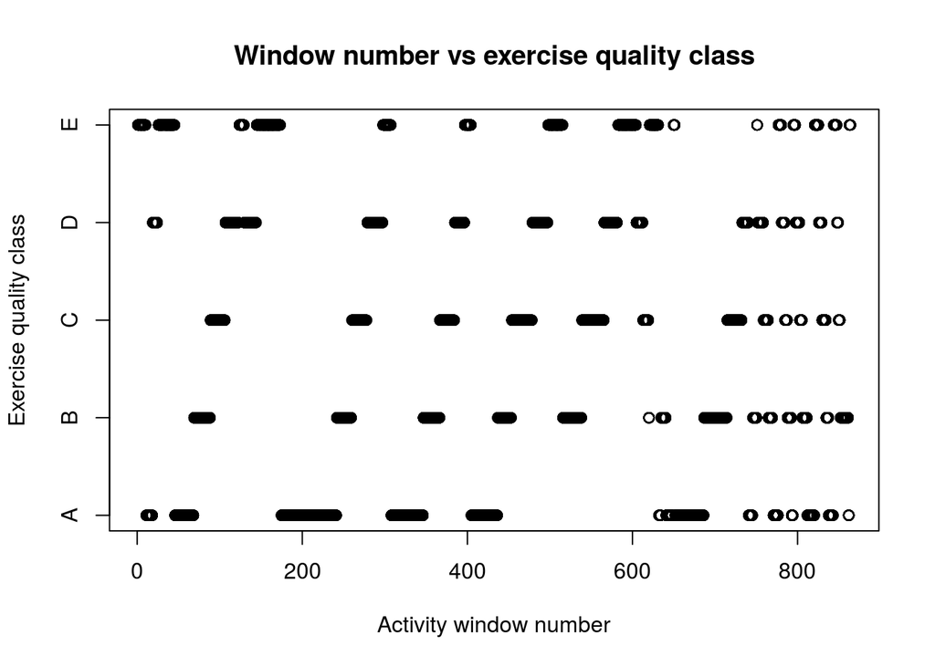

```r
with(mov1[inTrain,],plot(num_window,classe, yaxt='n',ylab="Exercise quality class",xlab="Activity window number", main="Window number vs exercise quality class"))
axis(side=2, at=1:5, labels=levels(mov1$classe))
```

To clarify the plot, let’s be more precise and answer the question are all observations sharing same value of **num_window** also belonging to the same **classe**?

```r
## Are all cases in num_window belonging to the same classe?
all(sapply(unique(mov1$num_window), function(x)  length(unique(mov1[mov1$num_window==x,]$classe))==1))
```

```
## [1] TRUE
```

*So, in our trivial model, we simply look at the current test case and find the classe of observations from the training set that belong to the same num_window.* In the case that there is no such set of observations in the training set, by arbitrary choice return the default class, the class of the first observation in training set.

```r
predder=function(window,train)
  {
  if (length(train[train$num_window==window,]$classe)>0){
    train[train$num_window==window,]$classe[1]
    }
  else
    {
      train$classe[1]
      }
  }
predd=function(newset,train)
  {
  res=sapply(newset$num_window,function(x){predder(x,train)})
  res
  }
```

```r
mov1.filtered2Tr=mov1[inTrain,-c(cols,1,3,4,5,6)] ## retain num_window
# speedup by pre-filtering
#filt1=mov1.filtered2Tr[!duplicated(mov1.filtered2Tr[,c("num_window")]),]

sum=0
for(i in 0:9){
  begin=as.integer(nrow(mov1.filtered2Tr)/10)*i+min(i,nrow(mov1.filtered2Tr)%%10)+1
  end=begin+as.integer(nrow(mov1.filtered2Tr)/10)+as.integer(i<(nrow(mov1.filtered2Tr)%%10))-1
  sprintf('begin %f',begin)
  sprintf('end %f',end)
  #mov1.filtered2Ts=mov1[-inTrain,-c(cols,1,3,4,5,6)] ## retain num_window
  #to speed up the model
  temp=mov1.filtered2Tr[-(shuffle1[begin:end]),]
  filt1=temp[!duplicated(temp[,c("num_window")]),]

  sum=sum+accuracy(predd(mov1.filtered2Tr[shuffle1[begin:end],],filt1),mov1.filtered2Tr[shuffle1[begin:end],]$classe)
  }
sprintf('Estimated accuracy: %f',sum/10)
```

```
## [1] "Estimated accuracy: 0.999854"
```

We can see that the estimated out-of-sample accuracy for trivial model **over the partitions in training set** is not perfect 1, and that is because in some partitionings, all observations for some *num_window* can be outside of training set. However, this is not the case for the unlabeled test set:

```r
## Are there observation in the training set for each num_window in unlabeled test set?
all(mov2$num_window %in% mov1$num_window)
```

```
## [1] TRUE
```

So, we expect that the accuracy on unlabeled test set to be 1. Of course, this model **works well EXCLUSIVELY on the given data. its performance on data with new, yet unobserved, num_windows will be very bad as it just returns default class regardless of any other information.**

### Other models

We also tried out random forest and multinomial logistic regression. The former takes quite longer to compute and does not improve on other models while at the same time also building its precision on user specifics, so we do not gain anything. The latter model is substantially weaker classifier than others.

### Final choice

Due to very good performance, we choose SVM model. This model is expected to be very good classifier for **existing set of users** even in future. On the other hand, for the trivial classifier it is very probable that it will achieve the best results on the unlabelled test set, but it does not generalize to any new measurements.

## References

1. Velloso, E.; Bulling, A.; Gellersen, H.; Ugulino, W.; Fuks, H. Qualitative Activity Recognition of Weight Lifting Exercises. Proceedings of 4th International Conference in Cooperation with SIGCHI (Augmented Human ’13) . Stuttgart, Germany: ACM SIGCHI, 2013.